# Analiza czytelności wykresów – raport z ankiety

Michalina Duda, Gerard Mańkowski

2025-05-13

## Eksperyment 1

Eksperyment pierwszy dotyczył 6 różnych wykresów opisujących procentowy udział wybranych źródeł energii w Polsce. Są to wykresy: kołowy 2D, słupkowy oraz kołowy 3D kolorowe i szare. Celem eksperymentu jest zbadanie najlepszego sposobu na wizualizację procentowego udziału przedmiotów w całości oraz przeanalizowanie, czy kolor na wykresach pomoga odbiorcy w odczytaniu wyników. Przeprowadzono ankietę,  
w której zadano dwa pytania:

1. “Który z przedstawionych typów wykresów jest najbardziej przejrzysty i czytelny?”
2. “Który z orzedstawionych wykresów - kolorowy czy szary - jest bardziej przejrzysty i czytelny?”

### Wykresy

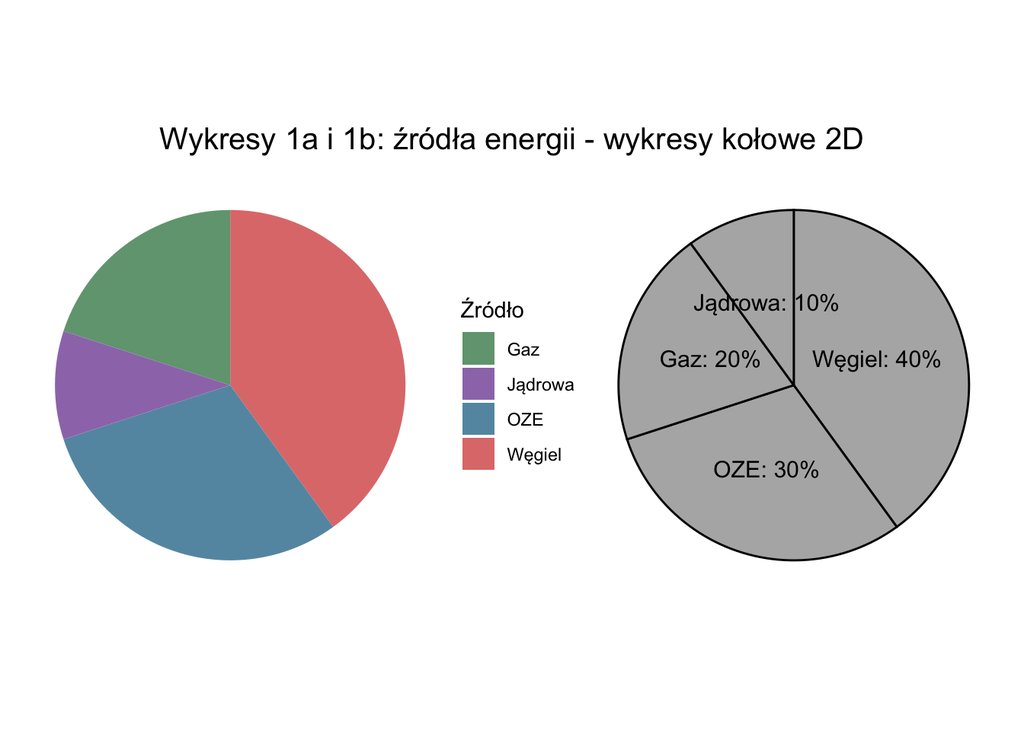

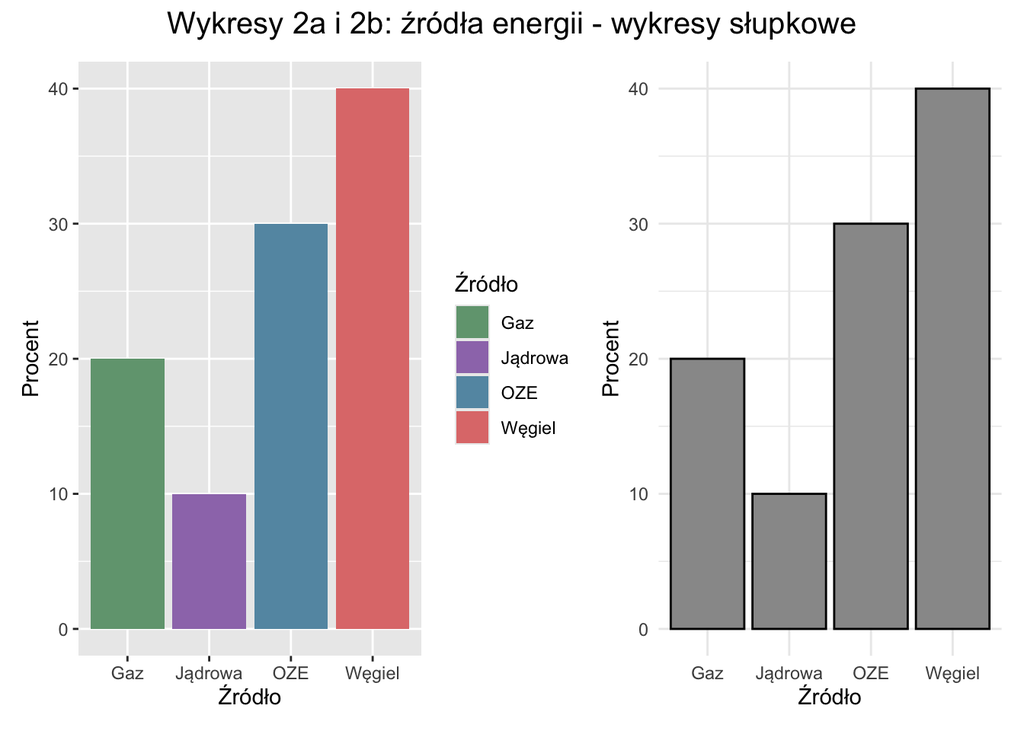

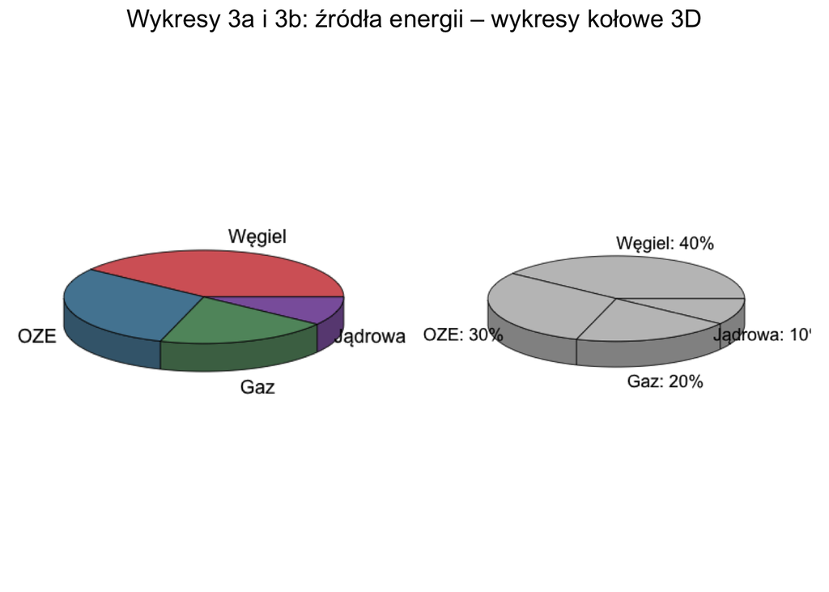

### Wyniki ankiety

Spośród 20 ankietowanych 11 osób odpowiedziało się za wykresem kołowym 2D, 7 osób za wykresem słupkowym i 2 osoby za wykresem kołowym 3D. Natomiast w pytaniu dotyczącym koloru wykresu 17 osób wybrało wykres kolorowy, a 3 osoby wykres szary.

### Wnioski

Z odpowiedzi ankietowanych można wywnioskować, że wykres kołowy 3D jest słabo czytelny, natomiast porównując wykresy kołowy 2D oraz słupkowy, ten pierwszy charakteryzuje się większą przejrzystością oraz czytelnością. Wyniki ankiety pokazują, że problem z odczytywaniem wykresu kołowego 3D nadal występuje w społeczeństwie. Jeżeli chodzi o kolor w wykresach, brak róźnorodności wpływa negatywnie na przejrzystość wyników.Użycie koloru sprawia, że wykres jest czytelniejszy.

## Eksperyment 2

Eksperyment drugi dotyczył 4 różnych typów wykresów opisujących liczbę zachorowań na COVID oraz grypę w miesiącach styczeń-czerwiec. Wykresy przedstawiające wyniki tych obserwacji to: liniowy, dot plot, słupkowy oraz heatmap. Zbadano jaki rodzaj wykresu jest najlepszy do obserwowania trendu występowania danego zjawiska - czy jest to wykres liniowy, jak uznaje się powszechnie?

### Wykresy

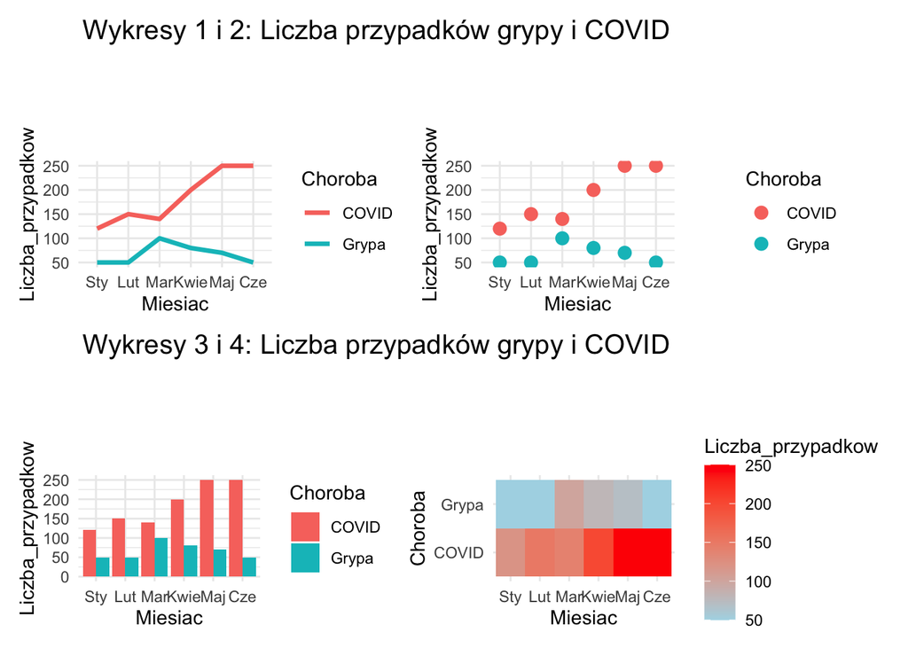

### Wyniki ankiety

Spośród 20 ankietowanych 10 osób odpowiedziało się za wykresem liniowym, 4 osoby za wykresem dot plot, 5 osób za wykresem słupkowym i 1 za wykresem typu heatmap.

### Wnioski

Z odpowiedzi ankietowanych można wywnioskować, że wykres typu heatmap, ze względu na swoją niedokładność, jest najmniej czytelny. Zgodnie z powszechnymi zasadami, wykres liniowy jest uważany za najbardziej przejrzysty i czytelny, zaraz po nim jest wykres słupkowy. Wyniki te pokazują, że najlepszą formą do obserwacji trendu jest linia, prosta do odczytania zjawiska.